# Risk Factor Analysis

## Outcome Variable

**Outcome Variable:** wast_rec90d

## Predictor Variables

**Intervention Variable:** nrooms

**Adjustment Set:**

- arm
- sex
- W_mage
- meducyrs
- feducyrs
- hhwealth_quart
- hfoodsec
- W_mhtcm
- W_nchldlt5
- W_parity
- impfloor
- impsan
- safeh20
- delta_W_mage
- delta_meducyrs
- delta_feducyrs
- delta_hhwealth_quart
- delta_hfoodsec
- delta_W_mhtcm
- delta_W_nchldlt5
- delta_W_parity
- delta_impfloor
- delta_impsan
- delta_safeh20

## Stratifying Variables

The analysis was stratified on these variable(s):

- agecat
- studyid
- country

## Data Summary

| agecat | studyid | country | nrooms | wast_rec90d | n_cell | n |
| --- | --- | --- | --- | --- | --- | --- |
| 0-24 months | ki0047075b-MAL-ED | BANGLADESH | 4+ | 0 | 3 | 121 |
| 0-24 months | ki0047075b-MAL-ED | BANGLADESH | 4+ | 1 | 1 | 121 |
| 0-24 months | ki0047075b-MAL-ED | BANGLADESH | 1 | 0 | 32 | 121 |
| 0-24 months | ki0047075b-MAL-ED | BANGLADESH | 1 | 1 | 61 | 121 |
| 0-24 months | ki0047075b-MAL-ED | BANGLADESH | 2 | 0 | 7 | 121 |
| 0-24 months | ki0047075b-MAL-ED | BANGLADESH | 2 | 1 | 9 | 121 |
| 0-24 months | ki0047075b-MAL-ED | BANGLADESH | 3 | 0 | 2 | 121 |
| 0-24 months | ki0047075b-MAL-ED | BANGLADESH | 3 | 1 | 6 | 121 |
| 0-24 months | ki0047075b-MAL-ED | BRAZIL | 4+ | 0 | 5 | 23 |
| 0-24 months | ki0047075b-MAL-ED | BRAZIL | 4+ | 1 | 12 | 23 |
| 0-24 months | ki0047075b-MAL-ED | BRAZIL | 1 | 0 | 0 | 23 |
| 0-24 months | ki0047075b-MAL-ED | BRAZIL | 1 | 1 | 0 | 23 |
| 0-24 months | ki0047075b-MAL-ED | BRAZIL | 2 | 0 | 0 | 23 |
| 0-24 months | ki0047075b-MAL-ED | BRAZIL | 2 | 1 | 2 | 23 |
| 0-24 months | ki0047075b-MAL-ED | BRAZIL | 3 | 0 | 1 | 23 |
| 0-24 months | ki0047075b-MAL-ED | BRAZIL | 3 | 1 | 3 | 23 |
| 0-24 months | ki0047075b-MAL-ED | INDIA | 4+ | 0 | 3 | 173 |
| 0-24 months | ki0047075b-MAL-ED | INDIA | 4+ | 1 | 9 | 173 |
| 0-24 months | ki0047075b-MAL-ED | INDIA | 1 | 0 | 27 | 173 |
| 0-24 months | ki0047075b-MAL-ED | INDIA | 1 | 1 | 38 | 173 |
| 0-24 months | ki0047075b-MAL-ED | INDIA | 2 | 0 | 23 | 173 |
| 0-24 months | ki0047075b-MAL-ED | INDIA | 2 | 1 | 41 | 173 |
| 0-24 months | ki0047075b-MAL-ED | INDIA | 3 | 0 | 14 | 173 |
| 0-24 months | ki0047075b-MAL-ED | INDIA | 3 | 1 | 18 | 173 |
| 0-24 months | ki0047075b-MAL-ED | NEPAL | 4+ | 0 | 14 | 92 |
| 0-24 months | ki0047075b-MAL-ED | NEPAL | 4+ | 1 | 39 | 92 |
| 0-24 months | ki0047075b-MAL-ED | NEPAL | 1 | 0 | 4 | 92 |
| 0-24 months | ki0047075b-MAL-ED | NEPAL | 1 | 1 | 23 | 92 |
| 0-24 months | ki0047075b-MAL-ED | NEPAL | 2 | 0 | 1 | 92 |
| 0-24 months | ki0047075b-MAL-ED | NEPAL | 2 | 1 | 5 | 92 |

[output cut: 354 more lines]

The following strata were considered:

- agecat: 0-24 months, studyid: ki0047075b-MAL-ED, country: BANGLADESH
- agecat: 0-24 months, studyid: ki0047075b-MAL-ED, country: BRAZIL
- agecat: 0-24 months, studyid: ki0047075b-MAL-ED, country: INDIA
- agecat: 0-24 months, studyid: ki0047075b-MAL-ED, country: NEPAL
- agecat: 0-24 months, studyid: ki0047075b-MAL-ED, country: PERU
- agecat: 0-24 months, studyid: ki0047075b-MAL-ED, country: SOUTH AFRICA
- agecat: 0-24 months, studyid: ki0047075b-MAL-ED, country: TANZANIA, UNITED REPUBLIC OF
- agecat: 0-24 months, studyid: ki1000108-CMC-V-BCS-2002, country: INDIA
- agecat: 0-24 months, studyid: ki1000108-IRC, country: INDIA
- agecat: 0-24 months, studyid: ki1017093b-PROVIDE, country: BANGLADESH
- agecat: 0-24 months, studyid: ki1017093c-NIH-Crypto, country: BANGLADESH
- agecat: 0-24 months, studyid: ki1113344-GMS-Nepal, country: NEPAL
- agecat: 0-24 months, studyid: ki1114097-CONTENT, country: PERU
- agecat: 0-24 months, studyid: ki1135781-COHORTS, country: INDIA
- agecat: 0-24 months, studyid: kiGH5241-JiVitA-3, country: BANGLADESH
- agecat: 0-24 months, studyid: kiGH5241-JiVitA-4, country: BANGLADESH
- agecat: 0-6 months, studyid: ki0047075b-MAL-ED, country: BANGLADESH
- agecat: 0-6 months, studyid: ki0047075b-MAL-ED, country: BRAZIL
- agecat: 0-6 months, studyid: ki0047075b-MAL-ED, country: INDIA
- agecat: 0-6 months, studyid: ki0047075b-MAL-ED, country: NEPAL
- agecat: 0-6 months, studyid: ki0047075b-MAL-ED, country: PERU
- agecat: 0-6 months, studyid: ki0047075b-MAL-ED, country: SOUTH AFRICA
- agecat: 0-6 months, studyid: ki0047075b-MAL-ED, country: TANZANIA, UNITED REPUBLIC OF
- agecat: 0-6 months, studyid: ki1000108-CMC-V-BCS-2002, country: INDIA
- agecat: 0-6 months, studyid: ki1000108-IRC, country: INDIA
- agecat: 0-6 months, studyid: ki1017093b-PROVIDE, country: BANGLADESH
- agecat: 0-6 months, studyid: ki1017093c-NIH-Crypto, country: BANGLADESH
- agecat: 0-6 months, studyid: ki1113344-GMS-Nepal, country: NEPAL
- agecat: 0-6 months, studyid: ki1114097-CONTENT, country: PERU
- agecat: 0-6 months, studyid: ki1135781-COHORTS, country: INDIA
- agecat: 0-6 months, studyid: kiGH5241-JiVitA-3, country: BANGLADESH
- agecat: 0-6 months, studyid: kiGH5241-JiVitA-4, country: BANGLADESH
- agecat: 6-24 months, studyid: ki0047075b-MAL-ED, country: BANGLADESH
- agecat: 6-24 months, studyid: ki0047075b-MAL-ED, country: BRAZIL
- agecat: 6-24 months, studyid: ki0047075b-MAL-ED, country: INDIA
- agecat: 6-24 months, studyid: ki0047075b-MAL-ED, country: NEPAL
- agecat: 6-24 months, studyid: ki0047075b-MAL-ED, country: PERU
- agecat: 6-24 months, studyid: ki0047075b-MAL-ED, country: SOUTH AFRICA
- agecat: 6-24 months, studyid: ki0047075b-MAL-ED, country: TANZANIA, UNITED REPUBLIC OF
- agecat: 6-24 months, studyid: ki1000108-CMC-V-BCS-2002, country: INDIA
- agecat: 6-24 months, studyid: ki1000108-IRC, country: INDIA
- agecat: 6-24 months, studyid: ki1017093b-PROVIDE, country: BANGLADESH
- agecat: 6-24 months, studyid: ki1017093c-NIH-Crypto, country: BANGLADESH
- agecat: 6-24 months, studyid: ki1113344-GMS-Nepal, country: NEPAL
- agecat: 6-24 months, studyid: ki1114097-CONTENT, country: PERU
- agecat: 6-24 months, studyid: ki1135781-COHORTS, country: INDIA
- agecat: 6-24 months, studyid: kiGH5241-JiVitA-3, country: BANGLADESH
- agecat: 6-24 months, studyid: kiGH5241-JiVitA-4, country: BANGLADESH

### Dropped Strata

Some strata were dropped due to rare outcomes:

- agecat: 0-24 months, studyid: ki0047075b-MAL-ED, country: BANGLADESH
- agecat: 0-24 months, studyid: ki0047075b-MAL-ED, country: BRAZIL
- agecat: 0-24 months, studyid: ki0047075b-MAL-ED, country: INDIA
- agecat: 0-24 months, studyid: ki0047075b-MAL-ED, country: NEPAL
- agecat: 0-24 months, studyid: ki0047075b-MAL-ED, country: PERU
- agecat: 0-24 months, studyid: ki0047075b-MAL-ED, country: SOUTH AFRICA
- agecat: 0-24 months, studyid: ki0047075b-MAL-ED, country: TANZANIA, UNITED REPUBLIC OF
- agecat: 0-24 months, studyid: ki1000108-CMC-V-BCS-2002, country: INDIA
- agecat: 0-24 months, studyid: ki1017093b-PROVIDE, country: BANGLADESH
- agecat: 0-24 months, studyid: ki1114097-CONTENT, country: PERU
- agecat: 0-24 months, studyid: ki1135781-COHORTS, country: INDIA
- agecat: 0-6 months, studyid: ki0047075b-MAL-ED, country: BANGLADESH
- agecat: 0-6 months, studyid: ki0047075b-MAL-ED, country: BRAZIL
- agecat: 0-6 months, studyid: ki0047075b-MAL-ED, country: INDIA
- agecat: 0-6 months, studyid: ki0047075b-MAL-ED, country: NEPAL
- agecat: 0-6 months, studyid: ki0047075b-MAL-ED, country: PERU
- agecat: 0-6 months, studyid: ki0047075b-MAL-ED, country: SOUTH AFRICA
- agecat: 0-6 months, studyid: ki0047075b-MAL-ED, country: TANZANIA, UNITED REPUBLIC OF
- agecat: 0-6 months, studyid: ki1000108-CMC-V-BCS-2002, country: INDIA
- agecat: 0-6 months, studyid: ki1000108-IRC, country: INDIA
- agecat: 0-6 months, studyid: ki1017093b-PROVIDE, country: BANGLADESH
- agecat: 0-6 months, studyid: ki1017093c-NIH-Crypto, country: BANGLADESH
- agecat: 0-6 months, studyid: ki1114097-CONTENT, country: PERU
- agecat: 0-6 months, studyid: ki1135781-COHORTS, country: INDIA
- agecat: 6-24 months, studyid: ki0047075b-MAL-ED, country: BANGLADESH
- agecat: 6-24 months, studyid: ki0047075b-MAL-ED, country: BRAZIL
- agecat: 6-24 months, studyid: ki0047075b-MAL-ED, country: INDIA
- agecat: 6-24 months, studyid: ki0047075b-MAL-ED, country: NEPAL
- agecat: 6-24 months, studyid: ki0047075b-MAL-ED, country: PERU
- agecat: 6-24 months, studyid: ki0047075b-MAL-ED, country: SOUTH AFRICA
- agecat: 6-24 months, studyid: ki0047075b-MAL-ED, country: TANZANIA, UNITED REPUBLIC OF
- agecat: 6-24 months, studyid: ki1000108-CMC-V-BCS-2002, country: INDIA
- agecat: 6-24 months, studyid: ki1000108-IRC, country: INDIA
- agecat: 6-24 months, studyid: ki1017093b-PROVIDE, country: BANGLADESH
- agecat: 6-24 months, studyid: ki1017093c-NIH-Crypto, country: BANGLADESH
- agecat: 6-24 months, studyid: ki1114097-CONTENT, country: PERU
- agecat: 6-24 months, studyid: ki1135781-COHORTS, country: INDIA
- agecat: 6-24 months, studyid: kiGH5241-JiVitA-3, country: BANGLADESH

## Methods Detail

We’re interested in the causal parameters $E[Y_a]$ for all values of $a \in \mathcal{A}$. These parameters represent the mean outcome if, possibly contrary to fact, we intervened to set all units to have $A=a$. Under the randomization and positivity assumptions, these are identified by the statistical parameters $\psi_a=E_W[E_{Y|A,W}(Y|A=a,W)]$. In addition, we’re interested in the mean of $Y$, $E[Y]$ under no intervention (the observed mean). We will estimate these parameters by using SuperLearner to fit the relevant likelihood factors – $E_{Y|A,W}(Y|A=a,W)$ and $p(A=a|W)$, and then updating our likelihood fit using a joint TMLE.

For unadjusted analyses ($W=\{\}$), initial likelihoods were estimated using Lrnr_glm to estimate the simple $E(Y|A)$ and Lrnr_mean to estimate $p(A)$. For adjusted analyses, a small library containing Lrnr_glmnet, Lrnr_xgboost, and Lrnr_mean was used.

Having estimated these parameters, we will then use the delta method to estimate relative risks and attributable risks relative to a prespecified baseline level of $A$.

# Results Detail

## Results Plots

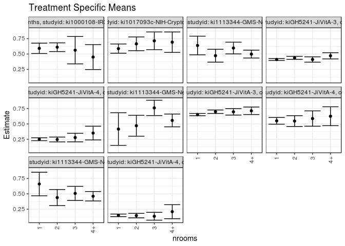

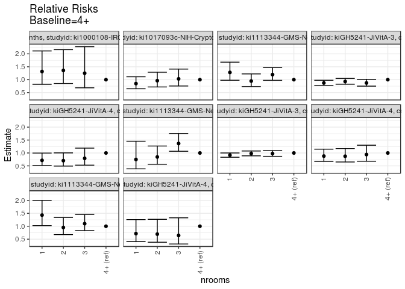

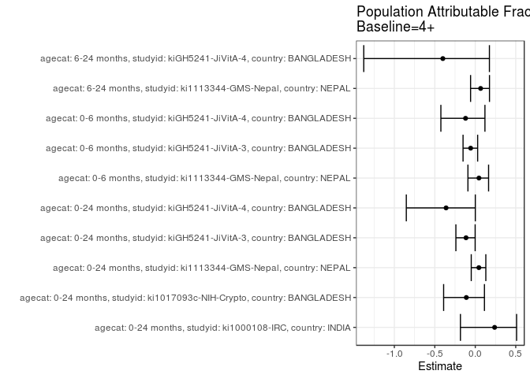

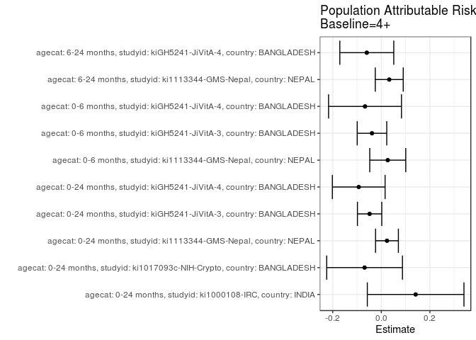

## Results Table

### Parameter: TSM

| agecat | studyid | country | intervention_level | baseline_level | estimate | ci_lower | ci_upper |
| --- | --- | --- | --- | --- | --- | --- | --- |
| 0-24 months | ki1000108-IRC | INDIA | 4+ | NA | 0.4500000 | 0.2471890 | 0.6528110 |
| 0-24 months | ki1000108-IRC | INDIA | 1 | NA | 0.5925926 | 0.5081592 | 0.6770260 |
| 0-24 months | ki1000108-IRC | INDIA | 2 | NA | 0.6111111 | 0.5401543 | 0.6820679 |
| 0-24 months | ki1000108-IRC | INDIA | 3 | NA | 0.5625000 | 0.3398407 | 0.7851593 |
| 0-24 months | ki1017093c-NIH-Crypto | BANGLADESH | 4+ | NA | 0.6927376 | 0.5265486 | 0.8589266 |
| 0-24 months | ki1017093c-NIH-Crypto | BANGLADESH | 1 | NA | 0.5884814 | 0.5135449 | 0.6634178 |
| 0-24 months | ki1017093c-NIH-Crypto | BANGLADESH | 2 | NA | 0.6663706 | 0.5545226 | 0.7782187 |
| 0-24 months | ki1017093c-NIH-Crypto | BANGLADESH | 3 | NA | 0.7152265 | 0.5710810 | 0.8593720 |
| 0-24 months | ki1113344-GMS-Nepal | NEPAL | 4+ | NA | 0.4989851 | 0.4349636 | 0.5630065 |
| 0-24 months | ki1113344-GMS-Nepal | NEPAL | 1 | NA | 0.6389889 | 0.4870654 | 0.7909123 |
| 0-24 months | ki1113344-GMS-Nepal | NEPAL | 2 | NA | 0.4723836 | 0.3676459 | 0.5771212 |
| 0-24 months | ki1113344-GMS-Nepal | NEPAL | 3 | NA | 0.5973593 | 0.5018816 | 0.6928371 |
| 0-24 months | kiGH5241-JiVitA-3 | BANGLADESH | 4+ | NA | 0.4709024 | 0.4201653 | 0.5216395 |
| 0-24 months | kiGH5241-JiVitA-3 | BANGLADESH | 1 | NA | 0.4107098 | 0.3957212 | 0.4256983 |
| 0-24 months | kiGH5241-JiVitA-3 | BANGLADESH | 2 | NA | 0.4379682 | 0.4139214 | 0.4620150 |
| 0-24 months | kiGH5241-JiVitA-3 | BANGLADESH | 3 | NA | 0.4107266 | 0.3672845 | 0.4541686 |
| 0-24 months | kiGH5241-JiVitA-4 | BANGLADESH | 4+ | NA | 0.3510430 | 0.2392674 | 0.4628187 |
| 0-24 months | kiGH5241-JiVitA-4 | BANGLADESH | 1 | NA | 0.2507622 | 0.2269816 | 0.2745428 |
| 0-24 months | kiGH5241-JiVitA-4 | BANGLADESH | 2 | NA | 0.2467026 | 0.2074932 | 0.2859119 |
| 0-24 months | kiGH5241-JiVitA-4 | BANGLADESH | 3 | NA | 0.2780169 | 0.2085183 | 0.3475154 |
| 0-6 months | ki1113344-GMS-Nepal | NEPAL | 4+ | NA | 0.5568182 | 0.4527929 | 0.6608435 |
| 0-6 months | ki1113344-GMS-Nepal | NEPAL | 1 | NA | 0.4166667 | 0.1509081 | 0.6824252 |
| 0-6 months | ki1113344-GMS-Nepal | NEPAL | 2 | NA | 0.4705882 | 0.3004500 | 0.6407264 |
| 0-6 months | ki1113344-GMS-Nepal | NEPAL | 3 | NA | 0.7608696 | 0.6358674 | 0.8858717 |
| 0-6 months | kiGH5241-JiVitA-3 | BANGLADESH | 4+ | NA | 0.7139405 | 0.6524325 | 0.7754484 |
| 0-6 months | kiGH5241-JiVitA-3 | BANGLADESH | 1 | NA | 0.6519547 | 0.6338031 | 0.6701063 |
| 0-6 months | kiGH5241-JiVitA-3 | BANGLADESH | 2 | NA | 0.6984403 | 0.6698166 | 0.7270641 |
| 0-6 months | kiGH5241-JiVitA-3 | BANGLADESH | 3 | NA | 0.6967224 | 0.6441933 | 0.7492514 |
| 0-6 months | kiGH5241-JiVitA-4 | BANGLADESH | 4+ | NA | 0.6255026 | 0.4718860 | 0.7791191 |
| 0-6 months | kiGH5241-JiVitA-4 | BANGLADESH | 1 | NA | 0.5502388 | 0.4953521 | 0.6051255 |
| 0-6 months | kiGH5241-JiVitA-4 | BANGLADESH | 2 | NA | 0.5464195 | 0.4584056 | 0.6344335 |
| 0-6 months | kiGH5241-JiVitA-4 | BANGLADESH | 3 | NA | 0.5874655 | 0.4627034 | 0.7122276 |
| 6-24 months | ki1113344-GMS-Nepal | NEPAL | 4+ | NA | 0.4608107 | 0.3839773 | 0.5376441 |
| 6-24 months | ki1113344-GMS-Nepal | NEPAL | 1 | NA | 0.6596886 | 0.4677832 | 0.8515940 |
| 6-24 months | ki1113344-GMS-Nepal | NEPAL | 2 | NA | 0.4389645 | 0.3083171 | 0.5696118 |
| 6-24 months | ki1113344-GMS-Nepal | NEPAL | 3 | NA | 0.5069723 | 0.3920194 | 0.6219252 |
| 6-24 months | kiGH5241-JiVitA-4 | BANGLADESH | 4+ | NA | 0.2090985 | 0.0949812 | 0.3232157 |
| 6-24 months | kiGH5241-JiVitA-4 | BANGLADESH | 1 | NA | 0.1496088 | 0.1282309 | 0.1709868 |
| 6-24 months | kiGH5241-JiVitA-4 | BANGLADESH | 2 | NA | 0.1453674 | 0.1087438 | 0.1819911 |
| 6-24 months | kiGH5241-JiVitA-4 | BANGLADESH | 3 | NA | 0.1347573 | 0.0711028 | 0.1984117 |

### Parameter: E(Y)

| agecat | studyid | country | intervention_level | baseline_level | estimate | ci_lower | ci_upper |
| --- | --- | --- | --- | --- | --- | --- | --- |
| 0-24 months | ki1000108-IRC | INDIA | NA | NA | 0.5913706 | 0.5391835 | 0.6435576 |
| 0-24 months | ki1017093c-NIH-Crypto | BANGLADESH | NA | NA | 0.6237942 | 0.5698223 | 0.6777662 |
| 0-24 months | ki1113344-GMS-Nepal | NEPAL | NA | NA | 0.5222816 | 0.4773852 | 0.5671781 |
| 0-24 months | kiGH5241-JiVitA-3 | BANGLADESH | NA | NA | 0.4226600 | 0.4115317 | 0.4337883 |
| 0-24 months | kiGH5241-JiVitA-4 | BANGLADESH | NA | NA | 0.2580019 | 0.2386523 | 0.2773515 |
| 0-6 months | ki1113344-GMS-Nepal | NEPAL | NA | NA | 0.5833333 | 0.5108676 | 0.6557991 |
| 0-6 months | kiGH5241-JiVitA-3 | BANGLADESH | NA | NA | 0.6754701 | 0.6621313 | 0.6888089 |
| 0-6 months | kiGH5241-JiVitA-4 | BANGLADESH | NA | NA | 0.5583942 | 0.5167799 | 0.6000084 |
| 6-24 months | ki1113344-GMS-Nepal | NEPAL | NA | NA | 0.4934383 | 0.4388573 | 0.5480193 |
| 6-24 months | kiGH5241-JiVitA-4 | BANGLADESH | NA | NA | 0.1492734 | 0.1316631 | 0.1668838 |

### Parameter: RR

| agecat | studyid | country | intervention_level | baseline_level | estimate | ci_lower | ci_upper |
| --- | --- | --- | --- | --- | --- | --- | --- |
| 0-24 months | ki1000108-IRC | INDIA | 4+ | 4+ | 1.0000000 | 1.0000000 | 1.0000000 |
| 0-24 months | ki1000108-IRC | INDIA | 1 | 4+ | 1.3168724 | 0.8208567 | 2.1126135 |
| 0-24 months | ki1000108-IRC | INDIA | 2 | 4+ | 1.3580247 | 0.8527213 | 2.1627595 |
| 0-24 months | ki1000108-IRC | INDIA | 3 | 4+ | 1.2500000 | 0.6860395 | 2.2775656 |
| 0-24 months | ki1017093c-NIH-Crypto | BANGLADESH | 4+ | 4+ | 1.0000000 | 1.0000000 | 1.0000000 |
| 0-24 months | ki1017093c-NIH-Crypto | BANGLADESH | 1 | 4+ | 0.8495011 | 0.6486061 | 1.1126201 |
| 0-24 months | ki1017093c-NIH-Crypto | BANGLADESH | 2 | 4+ | 0.9619381 | 0.7179920 | 1.2887676 |
| 0-24 months | ki1017093c-NIH-Crypto | BANGLADESH | 3 | 4+ | 1.0324638 | 0.7558176 | 1.4103689 |
| 0-24 months | ki1113344-GMS-Nepal | NEPAL | 4+ | 4+ | 1.0000000 | 1.0000000 | 1.0000000 |
| 0-24 months | ki1113344-GMS-Nepal | NEPAL | 1 | 4+ | 1.2805771 | 0.9772699 | 1.6780194 |
| 0-24 months | ki1113344-GMS-Nepal | NEPAL | 2 | 4+ | 0.9466888 | 0.7327385 | 1.2231098 |
| 0-24 months | ki1113344-GMS-Nepal | NEPAL | 3 | 4+ | 1.1971487 | 0.9750177 | 1.4698861 |
| 0-24 months | kiGH5241-JiVitA-3 | BANGLADESH | 4+ | 4+ | 1.0000000 | 1.0000000 | 1.0000000 |
| 0-24 months | kiGH5241-JiVitA-3 | BANGLADESH | 1 | 4+ | 0.8721759 | 0.7784891 | 0.9771375 |
| 0-24 months | kiGH5241-JiVitA-3 | BANGLADESH | 2 | 4+ | 0.9300616 | 0.8242335 | 1.0494775 |
| 0-24 months | kiGH5241-JiVitA-3 | BANGLADESH | 3 | 4+ | 0.8722116 | 0.7500432 | 1.0142791 |
| 0-24 months | kiGH5241-JiVitA-4 | BANGLADESH | 4+ | 4+ | 1.0000000 | 1.0000000 | 1.0000000 |
| 0-24 months | kiGH5241-JiVitA-4 | BANGLADESH | 1 | 4+ | 0.7143347 | 0.5124092 | 0.9958330 |
| 0-24 months | kiGH5241-JiVitA-4 | BANGLADESH | 2 | 4+ | 0.7027702 | 0.4923315 | 1.0031572 |
| 0-24 months | kiGH5241-JiVitA-4 | BANGLADESH | 3 | 4+ | 0.7919737 | 0.5283356 | 1.1871666 |
| 0-6 months | ki1113344-GMS-Nepal | NEPAL | 4+ | 4+ | 1.0000000 | 1.0000000 | 1.0000000 |
| 0-6 months | ki1113344-GMS-Nepal | NEPAL | 1 | 4+ | 0.7482993 | 0.3849793 | 1.4544986 |
| 0-6 months | ki1113344-GMS-Nepal | NEPAL | 2 | 4+ | 0.8451381 | 0.5625841 | 1.2696027 |
| 0-6 months | ki1113344-GMS-Nepal | NEPAL | 3 | 4+ | 1.3664596 | 1.0654962 | 1.7524342 |
| 0-6 months | kiGH5241-JiVitA-3 | BANGLADESH | 4+ | 4+ | 1.0000000 | 1.0000000 | 1.0000000 |
| 0-6 months | kiGH5241-JiVitA-3 | BANGLADESH | 1 | 4+ | 0.9131780 | 0.8341320 | 0.9997146 |
| 0-6 months | kiGH5241-JiVitA-3 | BANGLADESH | 2 | 4+ | 0.9782893 | 0.8892450 | 1.0762501 |
| 0-6 months | kiGH5241-JiVitA-3 | BANGLADESH | 3 | 4+ | 0.9758830 | 0.8702871 | 1.0942914 |
| 0-6 months | kiGH5241-JiVitA-4 | BANGLADESH | 4+ | 4+ | 1.0000000 | 1.0000000 | 1.0000000 |
| 0-6 months | kiGH5241-JiVitA-4 | BANGLADESH | 1 | 4+ | 0.8796747 | 0.6747814 | 1.1467827 |
| 0-6 months | kiGH5241-JiVitA-4 | BANGLADESH | 2 | 4+ | 0.8735688 | 0.6511540 | 1.1719539 |
| 0-6 months | kiGH5241-JiVitA-4 | BANGLADESH | 3 | 4+ | 0.9391896 | 0.6787105 | 1.2996366 |
| 6-24 months | ki1113344-GMS-Nepal | NEPAL | 4+ | 4+ | 1.0000000 | 1.0000000 | 1.0000000 |
| 6-24 months | ki1113344-GMS-Nepal | NEPAL | 1 | 4+ | 1.4315826 | 1.0236738 | 2.0020330 |
| 6-24 months | ki1113344-GMS-Nepal | NEPAL | 2 | 4+ | 0.9525917 | 0.6771445 | 1.3400848 |
| 6-24 months | ki1113344-GMS-Nepal | NEPAL | 3 | 4+ | 1.1001747 | 0.8299106 | 1.4584515 |
| 6-24 months | kiGH5241-JiVitA-4 | BANGLADESH | 4+ | 4+ | 1.0000000 | 1.0000000 | 1.0000000 |
| 6-24 months | kiGH5241-JiVitA-4 | BANGLADESH | 1 | 4+ | 0.7154947 | 0.4069808 | 1.2578794 |
| 6-24 months | kiGH5241-JiVitA-4 | BANGLADESH | 2 | 4+ | 0.6952105 | 0.3811153 | 1.2681663 |
| 6-24 months | kiGH5241-JiVitA-4 | BANGLADESH | 3 | 4+ | 0.6444680 | 0.3131133 | 1.3264815 |

### Parameter: PAR

| agecat | studyid | country | intervention_level | baseline_level | estimate | ci_lower | ci_upper |
| --- | --- | --- | --- | --- | --- | --- | --- |
| 0-24 months | ki1000108-IRC | INDIA | 4+ | NA | 0.1413706 | -0.0576416 | 0.3403827 |
| 0-24 months | ki1017093c-NIH-Crypto | BANGLADESH | 4+ | NA | -0.0689434 | -0.2249644 | 0.0870776 |
| 0-24 months | ki1113344-GMS-Nepal | NEPAL | 4+ | NA | 0.0232966 | -0.0237088 | 0.0703020 |
| 0-24 months | kiGH5241-JiVitA-3 | BANGLADESH | 4+ | NA | -0.0482424 | -0.0983546 | 0.0018697 |
| 0-24 months | kiGH5241-JiVitA-4 | BANGLADESH | 4+ | NA | -0.0930411 | -0.2016340 | 0.0155518 |
| 0-6 months | ki1113344-GMS-Nepal | NEPAL | 4+ | NA | 0.0265152 | -0.0475959 | 0.1006262 |
| 0-6 months | kiGH5241-JiVitA-3 | BANGLADESH | 4+ | NA | -0.0384703 | -0.0992844 | 0.0223437 |
| 0-6 months | kiGH5241-JiVitA-4 | BANGLADESH | 4+ | NA | -0.0671084 | -0.2172929 | 0.0830760 |
| 6-24 months | ki1113344-GMS-Nepal | NEPAL | 4+ | NA | 0.0326276 | -0.0249605 | 0.0902157 |
| 6-24 months | kiGH5241-JiVitA-4 | BANGLADESH | 4+ | NA | -0.0598250 | -0.1709251 | 0.0512751 |

### Parameter: PAF

| agecat | studyid | country | intervention_level | baseline_level | estimate | ci_lower | ci_upper |
| --- | --- | --- | --- | --- | --- | --- | --- |
| 0-24 months | ki1000108-IRC | INDIA | 4+ | NA | 0.2390558 | -0.1833208 | 0.5106685 |
| 0-24 months | ki1017093c-NIH-Crypto | BANGLADESH | 4+ | NA | -0.1105226 | -0.3910147 | 0.1134094 |
| 0-24 months | ki1113344-GMS-Nepal | NEPAL | 4+ | NA | 0.0446054 | -0.0497336 | 0.1304662 |
| 0-24 months | kiGH5241-JiVitA-3 | BANGLADESH | 4+ | NA | -0.1141401 | -0.2394667 | -0.0014857 |
| 0-24 months | kiGH5241-JiVitA-4 | BANGLADESH | 4+ | NA | -0.3606217 | -0.8522035 | 0.0004925 |
| 0-6 months | ki1113344-GMS-Nepal | NEPAL | 4+ | NA | 0.0454545 | -0.0906256 | 0.1645556 |
| 0-6 months | kiGH5241-JiVitA-3 | BANGLADESH | 4+ | NA | -0.0569534 | -0.1510092 | 0.0294165 |
| 0-6 months | kiGH5241-JiVitA-4 | BANGLADESH | 4+ | NA | -0.1201811 | -0.4249912 | 0.1194292 |
| 6-24 months | ki1113344-GMS-Nepal | NEPAL | 4+ | NA | 0.0661230 | -0.0579334 | 0.1756322 |
| 6-24 months | kiGH5241-JiVitA-4 | BANGLADESH | 4+ | NA | -0.4007747 | -1.3779430 | 0.1748458 |